# Actividad 2.2

Manuel Abril

2025-04-19

```r
if (!require(BiocManager)) install.packages("BiocManager")

installifnot <- function(pkg) {
    if (!require(pkg, character.only = T)) {
        BiocManager::install(pkg)
    }
}
# BiocManager::install() # Actualiza paquetes instalados
installifnot("pd.mogene.1.0.st.v1")
installifnot("mogene10sttranscriptcluster.db")
installifnot("oligo")
installifnot("limma")
installifnot("Biobase")
installifnot("arrayQualityMetrics")
installifnot("genefilter")
installifnot("annotate")
installifnot("xtable")
installifnot("gplots")
installifnot("GOstats")

if (!requireNamespace("GEOquery", quietly = TRUE)) {
    install.packages("BiocManager")
    BiocManager::install("GEOquery")
}
library(GEOquery)
```

- Comparación entre tres tipos de cáncer de mama

Este estudio de caso se basa en un artículo cuyos datos están disponibles en GEO (Serie GSE1561). Los investigadores investigaron tres tipos de tumores de cáncer de mama: apocrino (APO), basal (BAS) y luminal (LUMI). La clasificación se basa en la resistencia de los tumores a los receptores de estrógenos y andrógenos. • Los tumores clasificados como “APO” son negativos para el receptor de estrógeno (ER-) y positivos para el receptor de andrógeno (AR+). • Aquellos clasificados como “LUMI” son ER+ y AR+ y • Aquellos clasificados como “BAS” son ER- y AR-

La asignación de cada muestra a un grupo experimental se puede obtener en este enlace. Obviamente, este es un estudio observacional, pero su análisis también se puede realizar utilizando un enfoque de modelo lineal. 1. 2. 3. Identifica los factores experimentales y sus niveles. Escribe la matriz de diseño asociada con este diseño de estudio. Construye la matriz de contraste necesaria para comparar cada tipo de tumor con los otros dos, es decir: a. “APO” vs “LUMI” b. “APO” vs “BAS” c. “LUMI” vs “BAS”

```r
workingDir <- getwd()
dataDir <- file.path(workingDir, "datos")
resultsDir <- file.path(workingDir, "resultados")
```

```r
gse <- getGEO("GSE1561", GSEMatrix = TRUE)
gse <- gse[[1]]
targets <- pData(gse)
head(targets[, 1:5])  # Ver columnas disponibles
```

```
                   title geo_accession                status submission_date
GSM26804 PF01 EpPpT2N0G2      GSM26804 Public on Jun 01 2005     Jul 14 2004
GSM26867 PF02 EpPpT4N1G2      GSM26867 Public on Jun 01 2005     Jul 14 2004
GSM26868 PF03 EpPpT3N0Gu      GSM26868 Public on Jun 01 2005     Jul 14 2004
GSM26869 PF04 EpPpT2N1G1      GSM26869 Public on Jun 01 2005     Jul 14 2004
GSM26870 PF05 EpPnT2N1G1      GSM26870 Public on Jun 01 2005     Jul 14 2004
GSM26871 PF06 EnPnT2N0G3      GSM26871 Public on Jun 01 2005     Jul 14 2004
         last_update_date
GSM26804      May 31 2013
GSM26867      May 31 2013
GSM26868      May 31 2013
GSM26869      May 31 2013
GSM26870      Jun 01 2005
GSM26871      May 31 2013
```

```r
write.csv(targets, file = "targets.csv", row.names = FALSE)
targets <- read.csv("targets2.csv")
table(targets$Group)
```

```
  Apocrine Basal-like    Luminal
         6         16         27
```

```r
library(Biobase)
# TARGETS
targetsDF <- read.csv("targets2.csv", header = TRUE, sep = ",")
# Definir las variables para las gráficas
sampleNames <- as.character(targetsDF$SampleName)
group <- as.character(targetsDF$Group)
# Creamos un objeto AnnotatedDataFrame
targets <- AnnotatedDataFrame(targetsDF)
```

Ahora leemos los archivos CEL

```r
CELfiles <- targetsDF$FileName
rawData <- read.celfiles(file.path("datos", CELfiles), phenoData = targets)
```

[output not shown]

```r
rawData
```

```
ExpressionFeatureSet (storageMode: lockedEnvironment)
assayData: 506944 features, 49 samples
  element names: exprs
protocolData
  rowNames: 1 2 ... 49 (49 total)
  varLabels: exprs dates
  varMetadata: labelDescription channel
phenoData
  rowNames: 1 2 ... 49 (49 total)
  varLabels: SampleName FileName Group
  varMetadata: labelDescription channel
featureData: none
experimentData: use 'experimentData(object)'
Annotation: pd.hg.u133a
```

# Exploración y control de calidad

## Boxplot

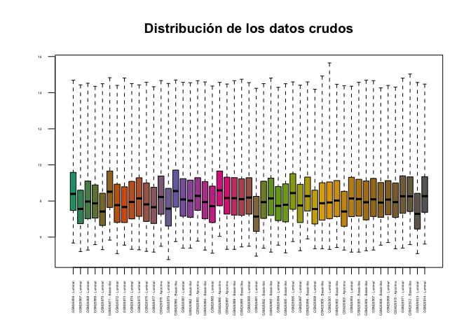

```r
# BOXPLOT
etiquetas <- paste(sampleNames, targetsDF$Group, sep = " - ")
sampleColor <- as.numeric(as.factor(targetsDF$Group))
boxplot(rawData, which = "all", las = 2, main = "Distribución de los datos crudos",
    cex.axis = 0.3, names = etiquetas)
```

## Clustering jerárquico

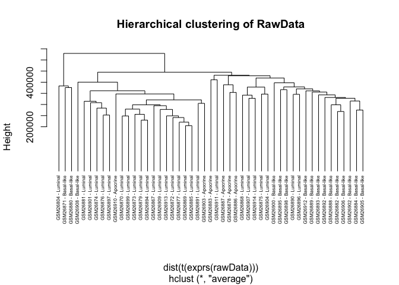

```r
# HIERARQUICAL CLUSTERING
etiquetas <- paste(sampleNames, targetsDF$Group, sep = " - ")
clust.euclid.average <- hclust(dist(t(exprs(rawData))), method = "average")
plot(clust.euclid.average, labels = etiquetas, main = "Hierarchical clustering of RawData",
    cex = 0.5, hang = -1)
```

## PCA

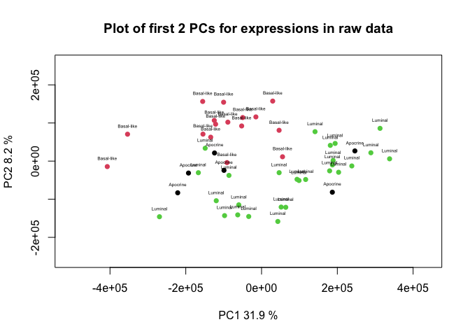

```r
# PRINCIPAL COMPONENT ANALYSIS
plotPCA <- function(X, labels = NULL, colors = NULL, dataDesc = "", scale = FALSE,
    formapunts = NULL, myCex = 0.3, ...) {
    pcX <- prcomp(t(X), scale = scale)  # o prcomp(t(X))
    loads <- round(pcX$sdev^2/sum(pcX$sdev^2) * 100, 1)
    xlab <- c(paste("PC1", loads[1], "%"))
    ylab <- c(paste("PC2", loads[2], "%"))
    if (is.null(colors))
        colors = 1
    plot(pcX$x[, 1:2], xlab = xlab, ylab = ylab, col = colors, pch = formapunts,
        xlim = c(min(pcX$x[, 1]) - 1e+05, max(pcX$x[, 1]) + 1e+05), ylim = c(min(pcX$x[,
            2]) - 1e+05, max(pcX$x[, 2]) + 1e+05))
    text(pcX$x[, 1], pcX$x[, 2], labels, pos = 3, cex = myCex)
    title(paste("Plot of first 2 PCs for expressions in", dataDesc, sep = " "), cex = 0.8)
}

groupFactor <- as.factor(targets$Group)
groupColors <- as.numeric(groupFactor)

plotPCA(exprs(rawData), labels = as.character(groupFactor), dataDesc = "raw data",
    colors = groupColors, formapunts = c(rep(16, length(groupFactor))), myCex = 0.4)
```

### Guardamos las tres imágenes en el folder

```r
# Guardar en un archivo
pdf(file.path("resultados", "QCPlots_Raw.pdf"))
boxplot(rawData, which = "all", las = 2, main = "Distribución de los datos crudos",
    cex.axis = 0.3, names = etiquetas)
plot(clust.euclid.average, labels = etiquetas, main = "Hierarchical clustering of RawData",
    cex = 0.5, hang = -1)
plotPCA(exprs(rawData), labels = as.character(groupFactor), dataDesc = "raw data",
    colors = groupColors, formapunts = c(rep(16, length(groupFactor))), myCex = 0.4)
dev.off()
```

# Control de calidad

```r
rerun <- FALSE
if (rerun) {
    arrayQualityMetrics(rawData, reporttitle = "QC_RawData", force = TRUE)
}
```

# Normalización

Utilzamos el método RMA

```r
eset <- rma(rawData)
```

```
Background correcting
Normalizing
Calculating Expression
```

```r
write.exprs(eset, file.path("resultados", "NormData.txt"))
eset
```

```
ExpressionSet (storageMode: lockedEnvironment)
assayData: 22283 features, 49 samples
  element names: exprs
protocolData
  rowNames: 1 2 ... 49 (49 total)
  varLabels: exprs dates
  varMetadata: labelDescription channel
phenoData
  rowNames: 1 2 ... 49 (49 total)
  varLabels: SampleName FileName Group
  varMetadata: labelDescription channel
featureData: none
experimentData: use 'experimentData(object)'
Annotation: pd.hg.u133a
```

# Filtrado

```r
library(genefilter)
annotation(eset) <- "hgu133a.db"  # Tuve que instalar los paquetes correspondientes
eset_filtered <- nsFilter(eset, var.func = IQR, var.cutoff = 0.75, var.filter = TRUE,
    require.entrez = TRUE, filterByQuantile = TRUE)
# NUMBER OF GENES REMOVED
print(eset_filtered)
```

```
$eset
ExpressionSet (storageMode: lockedEnvironment)
assayData: 3161 features, 49 samples
  element names: exprs
protocolData
  rowNames: 1 2 ... 49 (49 total)
  varLabels: exprs dates
  varMetadata: labelDescription channel
phenoData
  rowNames: 1 2 ... 49 (49 total)
  varLabels: SampleName FileName Group
  varMetadata: labelDescription channel
featureData: none
experimentData: use 'experimentData(object)'
Annotation: hgu133a.db

$filter.log
$filter.log$numDupsRemoved
[1] 7551

$filter.log$numLowVar
[1] 9482

$filter.log$numRemoved.ENTREZID
[1] 2079

$filter.log$feature.exclude
[1] 10
```

```r
# NUMBER OF GENES IN
print(eset_filtered$eset)
```

```
ExpressionSet (storageMode: lockedEnvironment)
assayData: 3161 features, 49 samples
  element names: exprs
protocolData
  rowNames: 1 2 ... 49 (49 total)
  varLabels: exprs dates
  varMetadata: labelDescription channel
phenoData
  rowNames: 1 2 ... 49 (49 total)
  varLabels: SampleName FileName Group
  varMetadata: labelDescription channel
featureData: none
experimentData: use 'experimentData(object)'
Annotation: hgu133a.db
```

La matriz de datos filtrados se extrae del objeto `filtered$eset$ y se utilizará en los pasos siguientes.

```r
filteredEset <- eset_filtered$eset
filteredData <- exprs(filteredEset)
colnames(filteredData) <- pData(eset_filtered$eset)$ShortName
```

# Selección de genes

Construimos un modelo lineal, es decir una matriz de diseño y una de contrastes, para el análisis.

## Construimos la matriz de diseño:

```r
library(limma)
treat <- pData(filteredEset)$Group
lev <- factor(treat, levels = unique(treat))
design <- model.matrix(~0 + lev)
colnames(design) <- levels(lev)
rownames(design) <- sampleNames
print(design)
```

```
         Luminal Basal-like Apocrine
GSM26804       1          0        0
GSM26867       1          0        0
GSM26868       1          0        0
GSM26869       1          0        0
GSM26870       1          0        0
GSM26871       0          1        0
GSM26872       1          0        0
GSM26873       1          0        0
GSM26874       1          0        0
GSM26875       1          0        0
GSM26876       1          0        0
GSM26877       1          0        0
GSM26878       0          0        1
GSM26879       1          0        0
GSM26880       0          1        0
GSM26881       1          0        0
GSM26882       0          1        0
GSM26883       0          0        1
GSM26884       0          1        0
GSM26885       1          0        0
GSM26886       0          0        1
GSM26887       0          0        1
GSM26888       0          1        0
GSM26889       0          1        0
GSM26890       1          0        0
 [ reached getOption("max.print") -- omitted 24 rows ]
attr(,"assign")
[1] 1 1 1
attr(,"contrasts")
attr(,"contrasts")$lev
[1] "contr.treatment"
```

## …A continuación la matriz de contraste:

```r
# COMPARISON
colnames(design) <- make.names(colnames(design))
cont.matrix1 <- makeContrasts(Luminal_vs_Basal = Luminal - Basal.like, Luminal_vs_Apocrine = Luminal -
    Apocrine, Apocrine_vs_Basal = Basal.like - Apocrine, levels = design)
comparisonName <- "Matriz de contraste"
print(cont.matrix1)
```

```
            Contrasts
Levels       Luminal_vs_Basal Luminal_vs_Apocrine Apocrine_vs_Basal
  Luminal                   1                   1                 0
  Basal.like               -1                   0                 1
  Apocrine                  0                  -1                -1
```

# Estimamos el modelo

```r
# MODEL FIT
fit1 <- lmFit(filteredData, design)
fit.main1 <- contrasts.fit(fit1, cont.matrix1)
fit.main1 <- eBayes(fit.main1)
```

## Contraste LUMINAL VS BASAL:

```r
topTab1 <- topTable(fit.main1, number = nrow(fit.main1), coef = "Luminal_vs_Basal",
    adjust = "fdr", lfc = 3, p.value = 0.05)
topTab1
```

```
              logFC   AveExpr         t      P.Value    adj.P.Val         B
205225_at  4.510828 10.119215 19.280162 2.144893e-25 6.780008e-22 47.050416
209603_at  3.347432  9.460454 15.352577 5.377348e-21 5.665932e-18 37.378862
204623_at  4.373967  9.793147 13.648874 7.482250e-19 4.730278e-16 32.599911
205009_at  4.339116  9.729226 10.721399 8.483460e-15 2.979580e-12 23.479934
209173_at  3.707822  9.778431 10.088117 7.369312e-14 1.663885e-11 21.357847
205044_at -3.758288  7.962444 -9.908675 1.371503e-13 2.890214e-11 20.747617
204580_at -3.565926  8.638286 -8.033304 1.100696e-10 6.822159e-09 14.170541
214079_at  3.788469  8.289198  7.462840 8.873254e-10 3.420531e-08 12.118082
206378_at  4.250904  8.789486  5.369209 1.853523e-06 1.791739e-05  4.629983
```

## Ahora, Luminal vs Apocrino:

```r
topTab2 <- topTable(fit.main1, number = nrow(fit.main1), coef = "Luminal_vs_Apocrine",
    adjust = "fdr", lfc = 3, p.value = 0.05)
topTab2
```

```
                logFC   AveExpr         t      P.Value    adj.P.Val         B
205225_at    4.229637 10.119215 12.637187 1.664419e-17 5.261229e-14 29.000247
217284_x_at -3.490805  8.166262 -9.361274 9.328115e-13 9.828723e-10 18.730022
211682_x_at -3.961823  7.760299 -8.717063 9.262184e-12 7.319441e-09 16.546173
206165_s_at -4.536155  6.921615 -7.443584 9.523163e-10 4.300388e-07 12.121055
203060_s_at -3.043639  8.712359 -7.201455 2.318220e-09 7.981368e-07 11.269572
214598_at   -3.501483  6.886759 -6.662964 1.679832e-08 4.424957e-06  9.373307
205009_at    3.574198  9.729226  6.173361 1.011289e-07 1.682465e-05  7.654754
205030_at   -4.889410  8.615719 -5.606758 7.909867e-07 7.813466e-05  5.687941
214451_at   -3.715319  6.800010 -5.174534 3.700952e-06 2.127038e-04  4.215863
202917_s_at -3.672283  9.420863 -4.722039 1.796072e-05 7.278697e-04  2.714031
203824_at   -3.243695  6.288565 -4.367430 5.988317e-05 1.631816e-03  1.574216
```

## Por último, Apocrino vs Basal

```r
topTab3 <- topTable(fit.main1, number = nrow(fit.main1), coef = "Apocrine_vs_Basal",
    adjust = "fdr", lfc = 3, p.value = 0.05)
topTab3
```

```
                logFC  AveExpr          t      P.Value    adj.P.Val         B
217284_x_at -4.405377 8.166262 -11.138231 2.100174e-15 6.638650e-12 24.696858
211682_x_at -4.587621 7.760299  -9.516702 5.394561e-13 5.684069e-10 19.363407
204942_s_at -3.843883 8.881508  -8.440306 2.511709e-11 1.024683e-08 15.652294
214079_at   -6.206420 8.289198  -8.057459 1.007974e-10 2.638738e-08 14.307162
205044_at    4.483455 7.962444   7.790313 2.672596e-10 5.280048e-08 13.362744
206165_s_at -4.671612 6.921615  -7.227443 2.106968e-09 2.296595e-07 11.362276
205498_at   -3.313835 7.381598  -7.128246 3.034407e-09 3.197254e-07 11.008856
206509_at   -5.330193 9.614936  -6.802941 1.004051e-08 9.617593e-07  9.849631
201525_at   -3.993120 9.908710  -6.312211 6.085159e-08 3.699074e-06  8.105214
214451_at   -4.760143 6.800010  -6.250559 7.625769e-08 4.304474e-06  7.886872
213680_at    3.324542 9.003829   6.150535 1.099237e-07 5.696208e-06  7.533186
209309_at   -3.875685 9.999964  -6.016306 1.793649e-07 8.337829e-06  7.059796
 [ reached 'max' / getOption("max.print") -- omitted 3 rows ]
```

## Verificar la información de los probes

```r
library(hgu133a.db)
keytypes(hgu133a.db)
```

```
 [1] "ACCNUM"       "ALIAS"        "ENSEMBL"      "ENSEMBLPROT"  "ENSEMBLTRANS"
 [6] "ENTREZID"     "ENZYME"       "EVIDENCE"     "EVIDENCEALL"  "GENENAME"
[11] "GENETYPE"     "GO"           "GOALL"        "IPI"          "MAP"
[16] "OMIM"         "ONTOLOGY"     "ONTOLOGYALL"  "PATH"         "PFAM"
[21] "PMID"         "PROBEID"      "PROSITE"      "REFSEQ"       "SYMBOL"
[26] "UCSCKG"       "UNIPROT"
```

```r
anotaciones <- AnnotationDbi::select(hgu133a.db, keys = rownames(filteredData), columns = c("ENTREZID",
    "SYMBOL"))
```

### Añadimos las columnas DE LOS GENES a la “topTable”.

### Primera: Luminal_vs_Basal

```r
library(dplyr)
topTabAnotada1 <- topTab1 %>%
    mutate(PROBEID = rownames(topTab1)) %>%
    left_join(anotaciones) %>%
    arrange(P.Value) %>%
    select(7, 8, 9, 1:6)

head(topTabAnotada1)
```

```
    PROBEID ENTREZID SYMBOL     logFC   AveExpr         t      P.Value
1 205225_at     2099   ESR1  4.510828 10.119215 19.280162 2.144893e-25
2 209603_at     2625  GATA3  3.347432  9.460454 15.352577 5.377348e-21
3 204623_at     7033   TFF3  4.373967  9.793147 13.648874 7.482250e-19
4 205009_at     7031   TFF1  4.339116  9.729226 10.721399 8.483460e-15
5 209173_at    10551   AGR2  3.707822  9.778431 10.088117 7.369312e-14
6 205044_at     2568  GABRP -3.758288  7.962444 -9.908675 1.371503e-13
     adj.P.Val        B
1 6.780008e-22 47.05042
2 5.665932e-18 37.37886
3 4.730278e-16 32.59991
4 2.979580e-12 23.47993
5 1.663885e-11 21.35785
6 2.890214e-11 20.74762
```

### Segunda: Luminal_vs_Apocrino

```r
topTabAnotada2 <- topTab2 %>%
    mutate(PROBEID = rownames(topTab2)) %>%
    left_join(anotaciones) %>%
    arrange(P.Value) %>%
    select(7, 8, 9, 1:6)

head(topTabAnotada2)
```

```
      PROBEID ENTREZID  SYMBOL     logFC   AveExpr         t      P.Value
1   205225_at     2099    ESR1  4.229637 10.119215 12.637187 1.664419e-17
2 217284_x_at   253190  SERHL2 -3.490805  8.166262 -9.361274 9.328115e-13
3 211682_x_at    54490 UGT2B28 -3.961823  7.760299 -8.717063 9.262184e-12
4 206165_s_at     9635   CLCA2 -4.536155  6.921615 -7.443584 9.523163e-10
5 203060_s_at     9060  PAPSS2 -3.043639  8.712359 -7.201455 2.318220e-09
6   214598_at     9073   CLDN8 -3.501483  6.886759 -6.662964 1.679832e-08
     adj.P.Val         B
1 5.261229e-14 29.000247
2 9.828723e-10 18.730022
3 7.319441e-09 16.546173
4 4.300388e-07 12.121055
5 7.981368e-07 11.269572
6 4.424957e-06  9.373307
```

### Segunda: Basal vs Apocrino

```r
topTabAnotada3 <- topTab3 %>%
    mutate(PROBEID = rownames(topTab3)) %>%
    left_join(anotaciones) %>%
    arrange(P.Value) %>%
    select(7, 8, 9, 1:6)

head(topTabAnotada3)
```

```
      PROBEID ENTREZID  SYMBOL     logFC  AveExpr          t      P.Value
1 217284_x_at   253190  SERHL2 -4.405377 8.166262 -11.138231 2.100174e-15
2 211682_x_at    54490 UGT2B28 -4.587621 7.760299  -9.516702 5.394561e-13
3 204942_s_at      222 ALDH3B2 -3.843883 8.881508  -8.440306 2.511709e-11
4   214079_at    10202   DHRS2 -6.206420 8.289198  -8.057459 1.007974e-10
5   205044_at     2568   GABRP  4.483455 7.962444   7.790313 2.672596e-10
6 206165_s_at     9635   CLCA2 -4.671612 6.921615  -7.227443 2.106968e-09
     adj.P.Val        B
1 6.638650e-12 24.69686
2 5.684069e-10 19.36341
3 1.024683e-08 15.65229
4 2.638738e-08 14.30716
5 5.280048e-08 13.36274
6 2.296595e-07 11.36228
```

#### Los resultados se escriben en dos archivos html:

```r
library(xtable)
write.csv2(topTabAnotada1, file = file.path("resultados", "Luminal_vs_Basal.csv"))
print(xtable(topTab1, align = "lllllll"), type = "html", html.table.attributes = "",
    file = file.path("resultados", "Luminal_vs_Basal.html"))
```

```r
library(xtable)
write.csv2(topTabAnotada2, file = file.path("resultados", "Luminal_vs_Apocrino.csv"))
print(xtable(topTab2, align = "lllllll"), type = "html", html.table.attributes = "",
    file = file.path("resultados", "Luminal_vs_Apocrino.html"))
```

```r
library(xtable)
write.csv2(topTabAnotada3, file = file.path("resultados", "Luminal_vs_Apocrino.csv"))
print(xtable(topTab3, align = "lllllll"), type = "html", html.table.attributes = "",
    file = file.path("resultados", "Luminal_vs_Apocrino.html"))
```

# Visualización de resultados:

## VP: Luminal v Basal

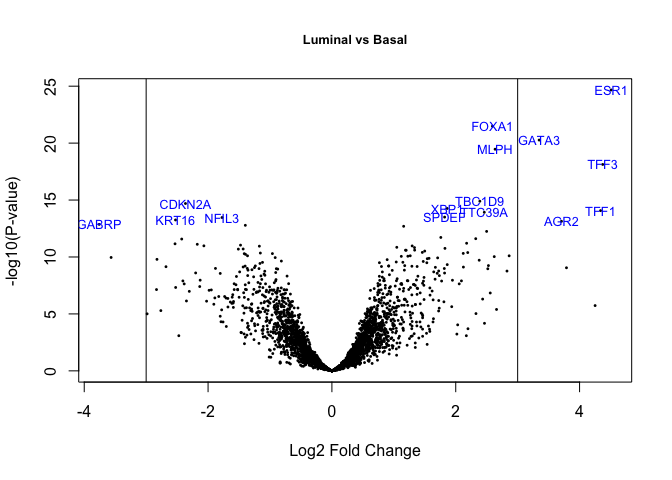

```r
# Volcano plot para Luminal vs Basal
library(hgu133a.db)

# Obtener anotaciones
annot <- AnnotationDbi::select(hgu133a.db, keys = rownames(fit.main1), columns = "SYMBOL",
    keytype = "PROBEID")
genenames <- annot$SYMBOL[match(rownames(fit.main1), annot$PROBEID)]

volcanoplot(fit.main1[, "Luminal_vs_Basal"], highlight = 15, names = genenames, main = "Luminal vs Basal",
    cex.main = 0.8, cex = 0.4)
abline(v = c(-3, 3))
```

```r
pdf(file.path("resultados", "Volcano_Luminal_vs_Basal.pdf"))
volcanoplot(fit.main1[, "Luminal_vs_Basal"], highlight = 15, names = genenames, main = "Luminal vs Basal",
    cex.main = 0.8, cex = 0.4)
abline(v = c(-3, 3))
dev.off()
```

## VP: Luminal v Apocrino

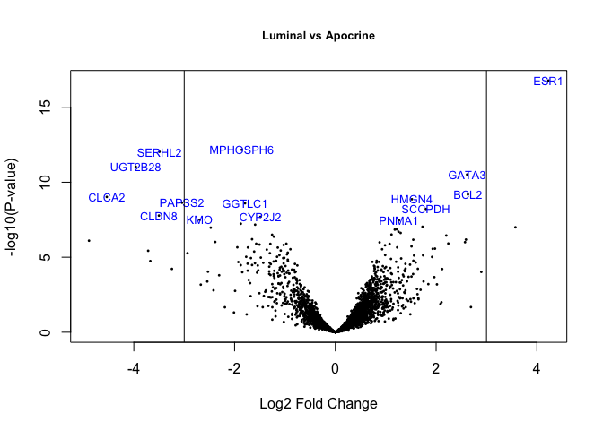

```r
# Volcano plot para Luminal vs Apocrine

library(hgu133a.db)

annot <- AnnotationDbi::select(hgu133a.db, keys = rownames(fit.main1), columns = "SYMBOL",
    keytype = "PROBEID")

volcanoplot(fit.main1[, "Luminal_vs_Apocrine"], highlight = 15, names = genenames,
    main = "Luminal vs Apocrine", cex.main = 0.8, cex = 0.4)
abline(v = c(-3, 3))
```

```r
pdf(file.path("resultados", "Volcano_Luminal_vs_Apocrine.pdf"))
volcanoplot(fit.main1[, "Luminal_vs_Apocrine"], highlight = 15, names = genenames,
    main = "Luminal vs Apocrine", cex.main = 0.8, cex = 0.4)
abline(v = c(-3, 3))
dev.off()
```

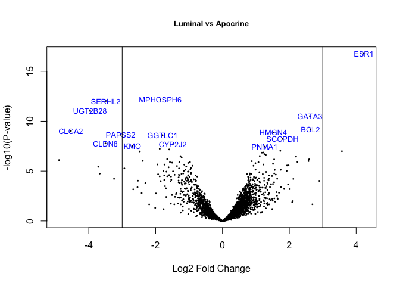

```r
# Volcano plot para Basal v Apocrino

library(hgu133a.db)

annot <- AnnotationDbi::select(hgu133a.db, keys = rownames(fit.main1), columns = "SYMBOL",
    keytype = "PROBEID")

volcanoplot(fit.main1[, "Luminal_vs_Apocrine"], highlight = 15, names = genenames,
    main = "Luminal vs Apocrine", cex.main = 0.8, cex = 0.4)
abline(v = c(-3, 3))
```

```r
pdf(file.path("resultados", "Volcano_Basal_vs_Apocrine.pdf"))
volcanoplot(fit.main1[, "Apocrine_vs_Basal"], highlight = 15, names = genenames,
    main = "Apocrine_vs_Basal", cex.main = 0.8, cex = 0.4)
abline(v = c(-3, 3))
dev.off()
```

## Heatmaps

### Heatmap (Luminal vs Basal)

```r
library(gplots)
# Filtramos el contraste
topTab <- topTable(fit.main1, coef = "Luminal_vs_Basal", lfc = 1, p.value = 0.05,
    number = 50)
selectedRows <- rownames(filteredData) %in% rownames(topTab)
selectedData <- filteredData[selectedRows, ]
sampleInfo <- pData(filteredEset)
muestrasUsar <- sampleInfo$Group %in% c("Luminal", "Basal.like")
selectedData <- selectedData[, muestrasUsar]
sampleGroups <- sampleInfo$Group[muestrasUsar]

# Cambiamos los probes por los nombres de genes.
library(AnnotationDbi)
library(hgu133a.db)
geneNames <- AnnotationDbi::select(hgu133a.db, keys = rownames(selectedData), columns = c("SYMBOL"),
    keytype = "PROBEID")
geneNames <- geneNames[match(rownames(selectedData), geneNames$PROBEID), ]
rownames(selectedData) <- geneNames$SYMBOL
selectedData <- selectedData[!is.na(rownames(selectedData)), ]

ColSideColors <- ifelse(sampleGroups == "Luminal", "red", "darkblue")

# HEATMAP
my_palette <- colorRampPalette(c("darkblue", "red"))(n = 299)
pdf(file = file.path("resultados", "heatmap_luminal_vs_basal.pdf"), width = 10, height = 10)
heatmap.2(selectedData, Rowv = TRUE, Colv = TRUE, main = "Luminal vs Basal (genes FC≥1, p<0.05)",
    cex.main = 0.8, scale = "row", col = my_palette, sepcolor = "white", sepwidth = c(0.05,
        0.05), cexRow = 0.5, cexCol = 0.9, key = TRUE, keysize = 1, density.info = "histogram",
    ColSideColors = ColSideColors, tracecol = NULL, srtCol = 30)
dev.off()
```

### Heatmap (Luminal vs Apocrino)

```r
# Filtrar genes significativos del contraste
topTab <- topTable(fit.main1, coef = "Luminal_vs_Apocrine", lfc = 1, p.value = 0.05,
    number = 50)
selectedRows <- rownames(filteredData) %in% rownames(topTab)
selectedData <- filteredData[selectedRows, ]
sampleInfo <- pData(filteredEset)
muestrasUsar <- sampleInfo$Group %in% c("Luminal", "Apocrine")
selectedData <- selectedData[, muestrasUsar]
sampleGroups <- sampleInfo$Group[muestrasUsar]

geneNames <- AnnotationDbi::select(hgu133a.db, keys = rownames(selectedData), columns = c("SYMBOL"),
    keytype = "PROBEID")
geneNames <- geneNames[match(rownames(selectedData), geneNames$PROBEID), ]
rownames(selectedData) <- geneNames$SYMBOL
selectedData <- selectedData[!is.na(rownames(selectedData)), ]
ColSideColors <- ifelse(sampleGroups == "Luminal", "red", "darkgreen")  # azul = Apocrine

my_palette <- colorRampPalette(c("black", "red"))(n = 299)
library(gplots)
pdf(file = file.path("resultados", "heatmap_luminal_vs_apocrino.pdf"), width = 10,
    height = 10)
heatmap.2(selectedData, Rowv = TRUE, Colv = TRUE, main = "Luminal vs Apocrine (genes FC≥1, p<0.05)",
    cex.main = 0.8, scale = "row", col = my_palette, sepcolor = "white", sepwidth = c(0.05,
        0.05), cexRow = 0.5, cexCol = 0.9, key = TRUE, keysize = 1, density.info = "histogram",
    ColSideColors = ColSideColors, tracecol = NULL, srtCol = 30)
dev.off()
```

### Heatmap (Basal vs Apocrino)

```r
# Filtrar genes significativos del contraste
topTab <- topTable(fit.main1, coef = "Apocrine_vs_Basal", lfc = 1, p.value = 0.05,
    number = 50)
selectedRows <- rownames(filteredData) %in% rownames(topTab)
selectedData <- filteredData[selectedRows, ]
sampleInfo <- pData(filteredEset)
muestrasUsar <- sampleInfo$Group %in% c("Luminal", "Apocrine")
selectedData <- selectedData[, muestrasUsar]
sampleGroups <- sampleInfo$Group[muestrasUsar]

geneNames <- AnnotationDbi::select(hgu133a.db, keys = rownames(selectedData), columns = c("SYMBOL"),
    keytype = "PROBEID")
geneNames <- geneNames[match(rownames(selectedData), geneNames$PROBEID), ]
rownames(selectedData) <- geneNames$SYMBOL
selectedData <- selectedData[!is.na(rownames(selectedData)), ]
ColSideColors <- ifelse(sampleGroups == "Luminal", "red", "darkgreen")  # azul = Apocrine

my_palette <- colorRampPalette(c("black", "red"))(n = 299)
library(gplots)
pdf(file = file.path("resultados", "heatmap_Apocrine_vs_Basal.pdf"), width = 10,
    height = 10)
heatmap.2(selectedData, Rowv = TRUE, Colv = TRUE, main = "Apocrine_vs_Basal", cex.main = 0.8,
    scale = "row", col = my_palette, sepcolor = "white", sepwidth = c(0.05, 0.05),
    cexRow = 0.5, cexCol = 0.9, key = TRUE, keysize = 1, density.info = "histogram",
    ColSideColors = ColSideColors, tracecol = NULL, srtCol = 30)
dev.off()
```

# Análisis de significación biológica

La mayoría de programas necesitan que los identificadores de los genes sean en formato “ENTREZ” por lo que prepararemos ambas listas a la vez (aunque ya teníamos la de los genes seleccionados).

```r
library(hgu133a.db)
probesUniverse <- rownames(filteredData)
entrezUniverse <- AnnotationDbi::select(hgu133a.db, keys = probesUniverse, columns = "ENTREZID",
    keytype = "PROBEID")$ENTREZID
topTab <- topTable(fit.main1, coef = "Luminal_vs_Basal", number = 50)
topProbes <- rownames(topTab)
entrezTop <- AnnotationDbi::select(hgu133a.db, keys = topProbes, columns = "ENTREZID",
    keytype = "PROBEID")
topGenes <- unique(na.omit(entrezTop$ENTREZID))
entrezUniverse <- entrezUniverse[!duplicated(entrezUniverse)]
```

```r
library(GOstats)

GOparams = new("GOHyperGParams", geneIds = topGenes, universeGeneIds = entrezUniverse,
    annotation = "hgu133a.db", ontology = "BP", pvalueCutoff = 0.01)
```

```r
GOhyper = hyperGTest(GOparams)
```

```r
head(summary(GOhyper))
```

```
      GOBPID       Pvalue OddsRatio   ExpCount Count Size
1 GO:1900101 7.249872e-05  66.11111 0.09517515     3    6
2 GO:0036499 2.464591e-04       Inf 0.03172505     2    2
3 GO:0060480 2.464591e-04       Inf 0.03172505     2    2
4 GO:0060481 2.464591e-04       Inf 0.03172505     2    2
5 GO:0060482 2.464591e-04       Inf 0.03172505     2    2
6 GO:1903897 2.464591e-04       Inf 0.03172505     2    2
                                                           Term
1 regulation of endoplasmic reticulum unfolded protein response
2                       PERK-mediated unfolded protein response
3                              lung goblet cell differentiation
4                         lobar bronchus epithelium development
5                                    lobar bronchus development
6         regulation of PERK-mediated unfolded protein response
```

```r
dim(summary(GOhyper))
```

```
[1] 44  7
```

```r
# Creamos un informe html con los resultados
GOfilename = file.path("resultados", "GOResults.html")
htmlReport(GOhyper, file = GOfilename, summary.args = list(htmlLinks = TRUE))
```